# 10.1. R Graphics

The S/R system was designed with publication quality graphics from the start. However, over time, new packages and facilities have been added to enhance the system.

# 10.1.1. Graphics Structure

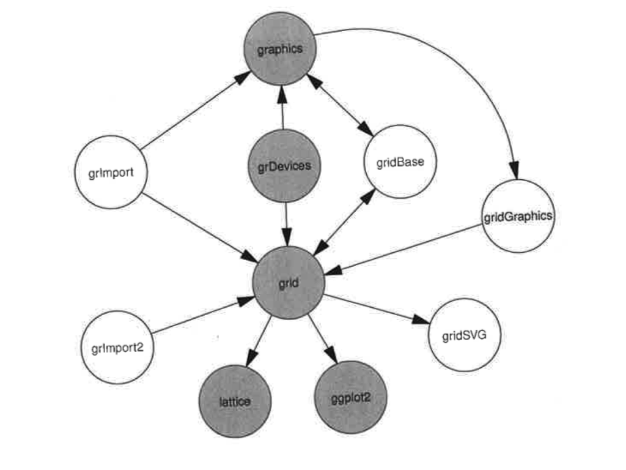

[*Source*: R Graphics by Paul Murrell.]

# 10.1.2. Base Graphics

To see what base graphics can do, try `demo(graphics)`.

Common functions are:

- `plot`, `lines`, `points` for common $x-y$ plots, adding lines, points
- `axes` for drawing axes, `box` for rectangular box
- `text`, `mtext` for placement of text
- `pairs` for scatterplot matrices, `coplot` for conditioning plots
- Some interactivity: `identify`, `locator`
- Higher level plots: `rug`, `dotchart`, `hist`, `barplot`, `boxplot`, `qqplot`, `qqnorm`, `image`

As we already saw, many R objects have default plotting methods. Every aspect of plotting can be controlled.

# 10.1.3. Graphics Devices

The graphics packages use low-level device software (in the `grDevices` package).

Eventual output is via screen software or document format.

Default device plots to the screen using standard system graphics: `quartz` on Mac, `x11` in Linux.

Many graphics devices are available and you can create devices that write to a file (e.g., `pdf` for pdf output, `png` for png, `jpeg` for jpeg, etc.).

To save a graphic that you have created, say in a `pdf` format, you use the corresponding graphic device, thus.

```r
pdf(file = "plot.pdf")
plot(x = 1:10, y = 1:10)
dev.off()
```

# 10.1.4. Graphics parameters

The `par` can be used to set graphics parameters, the most complicated function in R by some measure.

Things you can control.

- Layout, size, fonts
- Plot symbols, fill, line types
- Labels, annotations, text placement
- Axes, tickmarks
- Interactivity (`ask`)
- Colors
- Transparency (alpha blending) on some devices
- Support for plotting math symbols (`plotmath`

Grid equivalents are specified via `gpar`.

# 10.1.5. Example

Many objects in R have a default plotting method. What does that mean?

It means that you can pass that object to the `plot` function and the appropriate plot will be generated. Consider the following dataset.

```r
library(graphics)
data(pressure)
class(pressure)
```

```
## [1] "data.frame"
```

Let’s plot it.

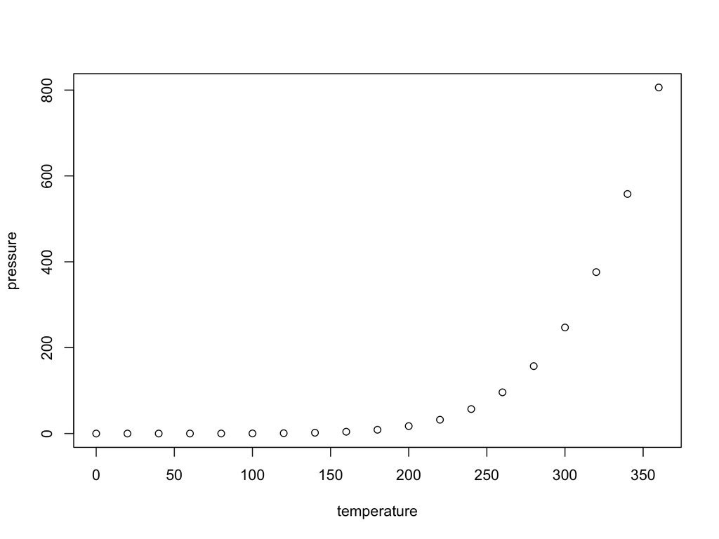

```r
plot(pressure)
```

Note how the plot function *knew* what to do with the data frame `pressure`. Let’s examine how this actually happens.

```r
plot
```

```
## function (x, y, ...)
## UseMethod("plot")
## <bytecode: 0x7f89aa68bb08>
## <environment: namespace:graphics>
```

shows that `plot` is a function in the `graphics` package.

A *generic function* is one that behaves differently depending on the class of its arguments.

Contrast with standard OOP where objects have methods and so a similarly named method `foo.plot()` and `bar.plot()` can potentially generate different types of plots for objects `foo` and `bar`.

A generic function is a functional way of achieving the same effect: `plot.foo` and `plot.bar` are functions that can be called if `foo` or `bar` are (respectively) passed to the `plot` function.

Let’s see what else `graphics` provides for plotting.

```r
str(pressure)
```

```
## 'data.frame':    19 obs. of  2 variables:
##  $ temperature: num  0 20 40 60 80 100 120 140 160 180 ...
##  $ pressure   : num  0.0002 0.0012 0.006 0.03 0.09 0.27 0.75 1.85 4.2 8.8 ...
```

```r
class(pressure)
```

```
## [1] "data.frame"
```

```r
ls(as.environment("package:graphics"), pattern = "^plot")
```

```
## [1] "plot"          "plot.default"  "plot.design"   "plot.function"
## [5] "plot.new"      "plot.window"   "plot.xy"
```

Hmmm, we don’t see a `plot.data.frame` which is what we were expecting to see. But such functions may yet be there and not visible for general use.

One way to find such functions is by looking at the *methods* for a generic function. These methods are the functions that actually do the real work.

```r
methods(plot, data.frame)
```

```
##  [1] plot,ANY-method        plot,color-method      plot.acf*
##  [4] plot.ACF*              plot.augPred*          plot.compareFits*
##  [7] plot.correspondence*   plot.data.frame*       plot.decomposed.ts*
## [10] plot.default           plot.dendrogram*       plot.density*
## [13] plot.ecdf              plot.factor*           plot.formula*
## [16] plot.function          plot.ggplot*           plot.gls*
## [19] plot.gtable*           plot.hcl_palettes*     plot.hclust*
## [22] plot.histogram*        plot.HoltWinters*      plot.intervals.lmList*
## [25] plot.isoreg*           plot.lda*              plot.lm*
## [28] plot.lme*              plot.lmList*           plot.mca*
## [31] plot.medpolish*        plot.mlm*              plot.nffGroupedData*
## [34] plot.nfnGroupedData*   plot.nls*              plot.nmGroupedData*
## [37] plot.pdMat*            plot.ppr*              plot.prcomp*
## [40] plot.princomp*         plot.profile*          plot.profile.nls*
## [43] plot.R6*               plot.ranef.lme*        plot.ranef.lmList*
## [46] plot.raster*           plot.ridgelm*          plot.shingle*
## [49] plot.simulate.lme*     plot.spec*             plot.stepfun
## [52] plot.stl*              plot.table*            plot.trans*
## [55] plot.trellis*          plot.ts                plot.tskernel*
## [58] plot.TukeyHSD*         plot.Variogram*
## see '?methods' for accessing help and source code
```

Notice that `plot.data.frame` is not visible, i.e. exported. However, we can still examine it using triple colon access:

```r
graphics:::plot.data.frame
```

```
## function (x, ...)
## {
##     plot2 <- function(x, xlab = names(x)[1L], ylab = names(x)[2L],
##         ...) plot(x[[1L]], x[[2L]], xlab = xlab, ylab = ylab,
##         ...)
##     if (!is.data.frame(x))
##         stop("'plot.data.frame' applied to non data frame")
##     if (ncol(x) == 1) {
##         x1 <- x[[1L]]
##         if (class(x1)[1L] %in% c("integer", "numeric"))
##             stripchart(x1, ...)
##         else plot(x1, ...)
##     }
##     else if (ncol(x) == 2) {
##         plot2(x, ...)
##     }
##     else {
##         pairs(data.matrix(x), ...)
##     }
## }
## <bytecode: 0x7f89aee62c40>
## <environment: namespace:graphics>
```

**NOTE** You will never use the triple colon functions in normal scripts and packages because those are not exported for a reason. In other words, you will only use the documented behaviors of a package to ensure your code always works!

So `plot(pressure)`, since it is generic, did the following:

- Determined the class of `pressure` and invoked the *method* plot for data.frame `graphics:::plot.data.frame(pressure)` since `pressure` is a data frame
- `graphics:::plot.data.frame` found that `pressure` had exactly 2 elements and therefore called the *internal* `plot2` function, which invoked `plot` one more time.
- The latter invocation tried to see if there was a method for `plot(x, y)` where `x` and `y` are numeric since `class(pressure[[1]])` is `numeric`. Finding no such method, it invoked `plot.default(pressure[[1]], pressure[[2]])`

# 10.1.6. Plot layouts

You can control how plots are laid out on a rectangular grid. For example, for two side-by-side plots:

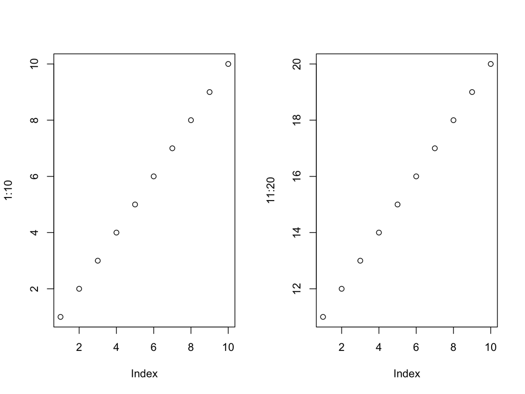

```r
opar <- par(mfrow=c(1,2)) ## 1 row, 2 cols
plot(1:10)
plot(11:20)
```

```r
par(opar)
```

**Warning** `par()` is one of the most complicated functions in base plotting. It has so many (interdependent) options that you will have to examine it in detail to get the effect you desire. Since it controls *global* plotting options, it has side effects.

Also note the general style of programming above that changes plotting parameters and retains the old settings in `opar` that you can restore, thereby avoiding unintended consequences for subsequent plots.

# 10.1.7. Building up plots

Every part of plotting can be controlled. So you can build up plots step by step.

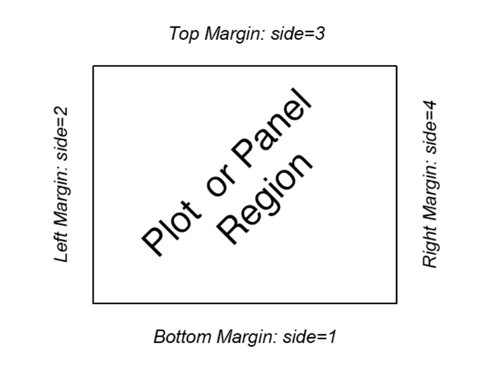

[*Source*: R Graphics by Paul Murrell.]

- Create an empty plot: `plot.new()`
- Set up the coordinate system: `plot.window(range(pressure$temperature), range(pressure$pressure))`
- Plot the xy points: `plot.xy(pressure, type="p")`
- Add lines to join the points also
- Draw a box around it: `box()`
- Now the axes, horizontal, vertical and top: `axis(1);axis(2); axis(3)`
- Add the title: `title(xlab=names(pressure)[1], ylab=names(pressure)[2])`

[output not shown]

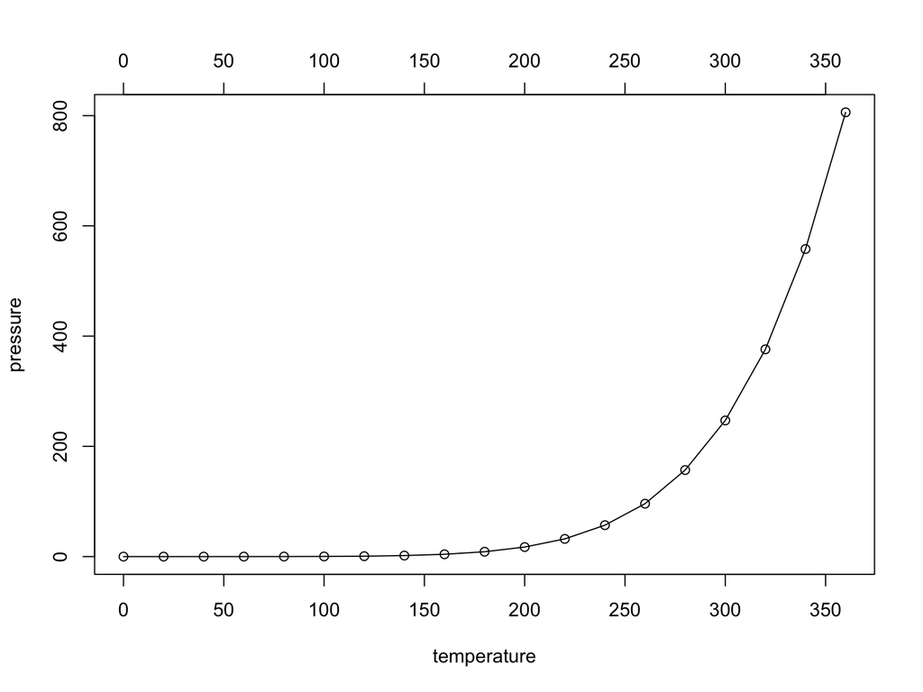

Compare with the above `plot(pressure)`.

# 10.1.8. Exporting plots

```r
pdf(file = "plot.pdf", width = 5, height = 3)
plot.new()
plot.window(range(pressure$temperature), range(pressure$pressure))
plot.xy(pressure, type = "p")
lines(pressure)
box()
axis(1); axis(2); axis(3)
title(xlab = names(pressure)[1], ylab = names(pressure)[2])
dev.off()
```

# 10.1.9. What to use?

- Base graphics is very capable, but has aged a bit. Cannot completely avoid it since it is used in many packages via `plot` methods.
- The `grid` by Paul Murrell provides a different graphics engine that can take the place of base graphics. It is clear that this is the modern way to go since you can deal with objects and manipulate various phases of the plotting process. However, this is *too low-level* for users.
- The `lattice` by Deepayan Sarkar, implements some of the ideas of Bill Cleveland’s Trellis graphics in R. Uses the `grid` package to render the plots. If you are very familiar with base graphics, it might be easier to find lattice plot equivalents.
- The `ggplot2` is recommended and widely popular. It is also based on `grid` (so good!). However, because it can take a while to really master it.